# Geolocation analysis with Open Source Tools 2016 North American Ornithological Congress, Washington D.C.

**Sponsored by:**

*Migrate Technology LLC.– www.migratetech.co.uk*

*The Cooper Ornithological Society*

*The National Science Foundation*

[figure not shown]

[figure not shown]

[figure not shown]

## Loading required packages

Be sure to acquire all required packages prior to running this analysis. See the [GetPackages.R script](https://github.com/Eli-S-Bridge/NAOC_Geos_2016/blob/master/GetPackages.R) to download all required packages if you haven’t done so already.

```r
library(SGAT)
library(BAStag)
library(GeoLight)
library(FLightR)
```

## Reading in the data

Here we read in the pre-processed data and calibration data - see [Preprocessing script](https://github.com/Eli-S-Bridge/NAOC_Geos_2016/blob/master/Preprocessing.R) and [Calibration script](https://github.com/Eli-S-Bridge/NAOC_Geos_2016/blob/master/Calibrartion.R) for more details.

```r
# opens and formats data straight from TAGS formatted csv file
Proc.data<-get.tags.data("data/A2_FLightR_twl.csv")
```

```
## Detected Intigeo_Mode_1 tag
## tag saved data every 300 seconds, and is assumed to measure data every 60 seconds, and write down max
```

```r
#loads object called Calibration
load("data/FLightR_calibration")
```

Here are what the data look like

```
## List of 12
##  $ Twilight.time.mat.dusk     : num [1:49, 1:339] 1.37e+09 1.37e+09 1.37e+09 1.37e+09 1.37e+09 ...
##  $ Twilight.log.light.mat.dusk: num [1:49, 1:339] 9.04 8.2 7.98 7.65 7.69 ...
##  $ Twilight.time.mat.dawn     : num [1:49, 1:339] 1.37e+09 1.37e+09 1.37e+09 1.37e+09 1.37e+09 ...
##  $ Twilight.log.light.mat.dawn: num [1:49, 1:339] 0.128 0.128 0.128 0.128 0.128 ...
##  $ measurement.period         : num 60
##  $ saving.period              : num 300
##  $ impute.on.boundaries       : logi FALSE
##  $ tagtype                    : chr "Intigeo_Mode_1"
##  $ log_tranformed             : logi FALSE
##  $ log.light.borders          : num [1:2] 1.5 9
##  $ log.irrad.borders          : num [1:2] -3 3
##  $ FLightR.data               :List of 2
##   ..$ Data     :'data.frame':    98311 obs. of  4 variables:
##   .. ..$ id   : num [1:98311] 1 2 3 4 5 6 7 8 9 10 ...
##   .. ..$ gmt  : POSIXct[1:98311], format: "2013-06-11 00:00:12" ...
##   .. ..$ light: num [1:98311] 1.14 1.14 1.14 1.14 1.14 ...
##   .. ..$ type : num [1:98311] 0 0 0 0 0 0 0 0 0 0 ...
##   ..$ twilights:'data.frame':    678 obs. of  5 variables:
##   .. ..$ datetime: POSIXct[1:678], format: "2013-06-11 02:25:10" ...
##   .. ..$ type    : int [1:678] 1 2 1 2 1 2 1 2 1 2 ...
##   .. ..$ light   : num [1:678] 4.49 4.49 4.49 4.49 4.49 4.49 4.49 4.49 4.49 4.49 ...
##   .. ..$ id      : num [1:678] 0 0 0 0 0 0 0 0 0 0 ...
##   .. ..$ excluded: num [1:678] 0 0 0 0 0 0 0 0 0 0 ...
```

# Establishing spatial grid

Here we establish a spatial grid and rules for possible migration paths. The default resolution is 50 x 50km grid cells. The inputs or terms for `left`, `right`, `bottom` and `top` define your bounding box. The argument `distance.from.land.allowed.to.use` should be a vector with length of two. The first number is a negative distance allowed to use while over land (restricts birds to flying only over coastlines and water) and second is distance from land allowed to use while over water (restricts birds to flying only over coastlines and land). The `distance.from.land.allowed.to.stay` should also be a vector of length two. The first number is negative distance where the bird is allowed to be stationary (restricts birds to landing only on coastlines and land). The second value is distance from land allowed to fly over during twilight while over water (restricts birds to landing only on coastlines and water). Use infinity `c(-Inf,Inf)` to not use any restrictions. We won’t restrict paths for this example here.

```r
Grid<-make.grid(left=-14,
                bottom=30,
                right=13,
                top=57,
                #Use infinity to withold restrictions on migration paths
                distance.from.land.allowed.to.use=c(-Inf, Inf),
                distance.from.land.allowed.to.stay=c(-Inf, Inf))
```

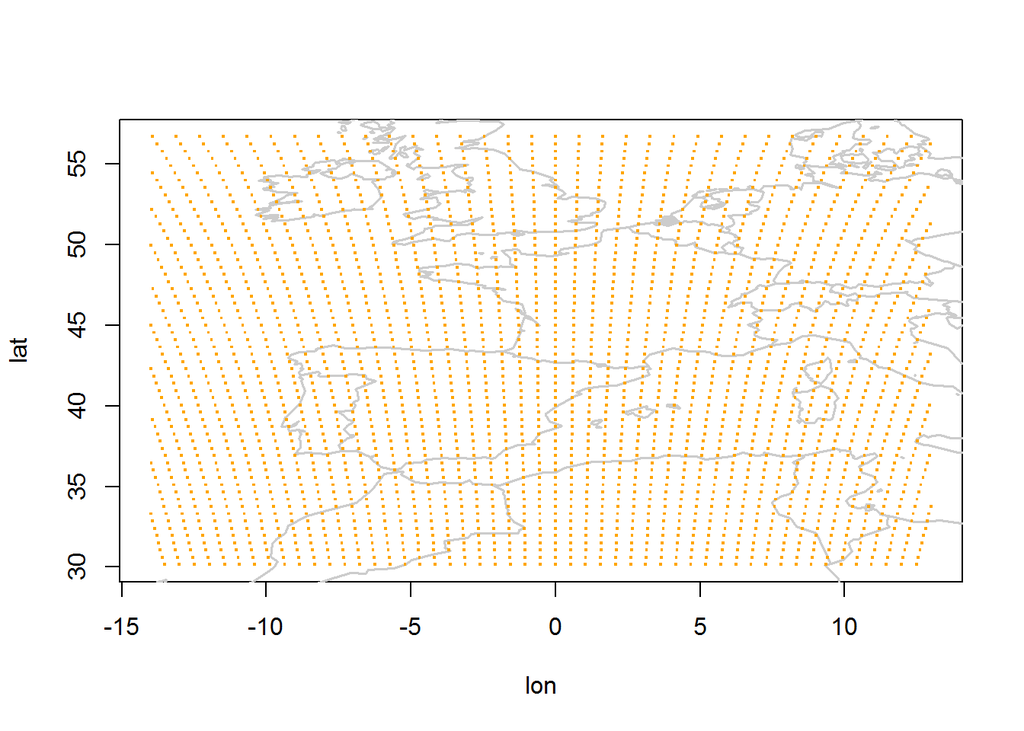

# Create a proposal

Here we create an array of settings and data that incorporates all the objects created at earlier steps:

```
- the light data with the detected twilight events (Proc.data)
- the spatial parameters (Grid)
- geographic coordinates of the starting location (start)
- the calibration parameters (Calibration)
```

This can take a while

```r
Sys.time()
```

```
## [1] "2016-08-10 10:32:49 EDT"
```

```r
a<-Sys.time()

all.in<-make.prerun.object(Proc.data = Proc.data,
                           Grid = Grid,
                           start = c(5.43, 52.93), # c(Longitude, Latitude)
                           Calibration = Calibration)
```

```
## making cluster
## estimating dusks
## estimating dawns
## processing results
```

```r
Sys.time()-a
```

```
## Time difference of 3.150917 mins
```

# Running the Particle Filter

Here is where the results are calculated (coordinates, behavior, stationarity). Within the `run.particle.filter` function, the following parameters can be preset:

```
-number of particles (1e4 is recommended for test and 1e6 for the analysis)
-known.last = TRUE if you know the track ends where it began  (FALSE is the default)
-check.outliers = TRUE, for the "on a fly" discard of outliers (only recommended to make pretty maps).
```

```r
nParticles=1e4     #just a quick trial

a <- Sys.time()

Result <- run.particle.filter(all.out = all.in,
                              threads=-1,
                              nParticles=nParticles,
                              known.last=TRUE,
                              precision.sd=25,
                              check.outliers=FALSE)
```

[output not shown]

[output cut: 5377 more lines]

```
## adding last points form the stack to the resutls
## +----------------------------------+
## |     estimated negative Log Likelihood is -159.4351
## +----------------------------------+
## estimating results object
## estimating quantiles for positions
## adding 95% credibility intervals to medians
##    estimating distances
##    estimating directions
##    estimating mean directions
##    estimating kappas
##    estimating mean dists
##    estimating probs of migration
##    estimating median dists
##    creating output DONE!
```

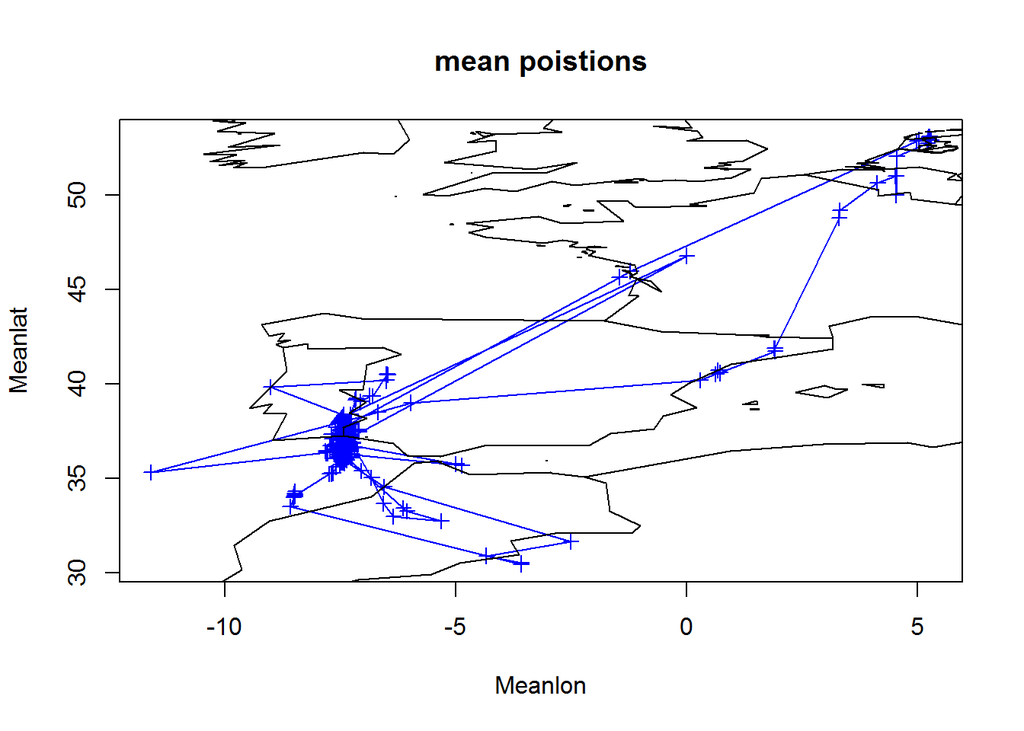

```
## DONE!
```

```r
Sys.time() - a
```

```
## Time difference of 2.990067 mins
```

Save your results as an RData object

```r
save(Result, file="data/A2_FLightR_results.RData")
load("data/A2_FLightR_results.RData")
```

# Plot the results

Plot a simple map

[figure not shown]

```r
#Plot a simple map
map.FLightR.ggmap(Result)
```

Plot and save a simple map

[figure not shown]

```r
map.FLightR.ggmap(Result, save.options = list(filename = "data/FLightR.map.pdf"))
```

Generate a plot that shows the longitude and latitude throughout the tracking period

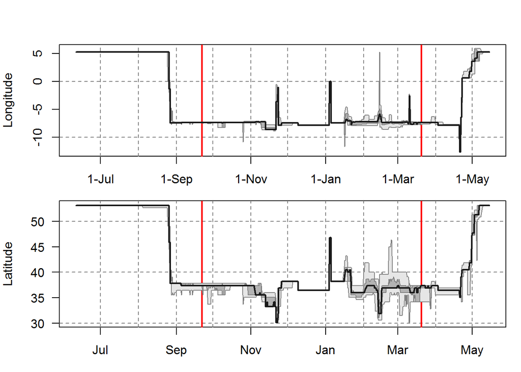

```r
plot.lon.lat(Result)
```

#### Exercise:

> Try restricting the migratory path to include only land as stationary periods.  
> Where in the process would you set that? Do the results differ? If so, how they differ?

[figure not shown]

[figure not shown]

[figure not shown]